# Practical 3 - Dimensionality Reduction and Clustering

This practical uses the data set from https://www.nature.com/articles/s41586-018-0654-5. This is single cell transcriptomics data from ~25,000 cells from the cortex. For each of these cells, the expression of several thousand genes was measured. In the original study, the authors were interested in clustering the cells into types.

We made a selection of 5000 cells and the 1000 most informative genes for run time reasons. We provide you with the original cell type labels determined by the authors for comparison.

```python
# Prepare
import numpy as np
import matplotlib.pyplot as plt
import seaborn as sns; sns.set(context='talk',style='white',palette='colorblind')
import pickle
import scipy
import matplotlib
from scipy import sparse
import sklearn
import sklearn.mixture
from sklearn.decomposition import PCA
from sklearn.manifold import TSNE
from sklearn.cluster import KMeans
import scipy as sp
```

## Task 0: Load and normalize count data

```python
def lognormalize_counts(tasic_dict):

    #normalize and logtransform counts
    counts = tasic_dict['counts']
    libsizes = counts.sum(axis=1)
    CPM = counts / libsizes * 1e+6
    logCPM = np.log2(CPM + 1)
    tasic_dict['logCPM'] = logCPM

    return tasic_dict
```

```python
tasic_1k = lognormalize_counts(pickle.load(open('tasic_subset_1kselectedpickle.sec', 'rb')))
```

## Task 1: Linear dimensionality reduction with PCA [15 points]

In this task, you will use principle component analysis (PCA) to reduce the dimensionality of the dataset.

First, implement PCA "by hand". You can use `numpy.linalg.eig()` but no `sklearn`-functions. Write a function that computes all possible principle components, and returns them along with the fraction of variance they explain.

```python
from sklearn.preprocessing import StandardScaler
```

```python
def PCA_manual(data):
    '''
    Function that performs PCA on the input data

    input: (cells,genes)-shaped array of log transformed cell counts
    output:
        fraction_variance_explained: (genes,)-shaped array with the fraction of variance explained by the individual PCs
        principal_components: (genes,genes)-shaped array containing the principal components as columns
    '''
    ### NOTE: Make sure the function returns the PCs sorted by the fraction of variance explained! ###
    ###       (First column of principal_components should hold the PC with the highest variance   ###
    ###       explained -- fraction_variance_explained should also be sorted accordingly)          ###

    # INSERT YOUR CODE HERE
    # We first center the data by column means to implement eigenvalue decomposition
    X = StandardScaler(with_std=False).fit_transform(data) # X: Centered data
    Xt = np.transpose(X) # take transpose of X
    C = np.cov(Xt) # Covariance matrix of X'
    values, vectors = np.linalg.eig(C) # Eigen value decomposition

    idx = np.argsort(values)[::-1] # Reverse sort and store the index positions
    principal_components = vectors[:,idx] # Arrange PCs according to largest to smallest eigenvalues
    evals = values[idx] # Arrange eigenvalues in descending

    fraction_variance_explained = [] # Empty vector to store explained fraction variance
    for i in range(len(values)):
        fraction_variance_explained.append(evals[i] / np.sum(values)) # Update the vector

    return fraction_variance_explained,principal_components
```

```python
var_expl, PCs = PCA_manual(tasic_1k['logCPM'])
```

Before we explore the structure of the low dimensional representation, we first want to know how much variance the first PCs explain:

- Plot the variance explained of the `n`-th PC vs. `n`
- Plot the cumulative variance explained for the `n` PCs with highest variance explained vs. `n`

From the latter plot you should be able to see how much PCs you need to keep to explain at least `x`% of the variance.

How many components to you need to keep to explain 50%, 75%, 90% and 99%, respectively? Indicate this in your plot.

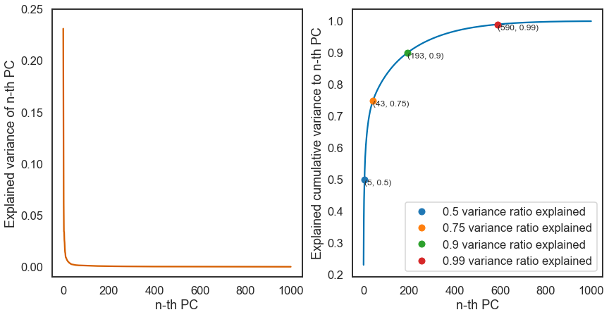

```
The number of PCs required to explain 0.5 variance ratio is: 5
The number of PCs required to explain 0.75 variance ratio is: 43
The number of PCs required to explain 0.9 variance ratio is: 193
The number of PCs required to explain 0.99 variance ratio is: 590
```

```python
plt.figure(figsize=(14,7))

# INSERT YOUR CODE HERE
n = range(1000) # number of PCs

plt.subplot(121) # Plot of PC vs. explained variance
plt.plot(n,var_expl, color = 'r')
plt.ylim((-0.01,0.25))
plt.xlabel('n-th PC')
plt.ylabel('Explained variance of n-th PC')

# INSERT YOUR CODE HERE

cum_variance = [] # initialize cumulative variance
temp = 0 # temporary counter
count = 0 # counter
tot_var = np.sum(var_expl) # total variance
percentage = np.array([0.50, 0.75, 0.90, 0.99])
var = tot_var*percentage # requied variance by percentage
req_n = [] # required number of PCs

for i in range(len(var_expl)): # loop over the number of variances explained by the PCs
    temp += var_expl[i] # cumulatively add the variances and store into temp
    cum_variance.append(temp) # update cumulative variance
    if count < len(var): # check if within variance count
        if temp >= var[count]: # check if required cumulative variance obtained
            req_n.append(i) # update the required number of PCs
            count += 1 # increment counter

colors = ["#1f77b4", "#ff7f0e", "#2ca02c", "#d62728","#9467bd", "#8c564b", "#e377c2", "#7f7f7f", "#bcbd22", "#17becf"]

plt.subplot(122)
plt.plot(n,cum_variance, color = 'b')
for i in range(len(req_n)):
    plt.plot(req_n[i],var[i],'o', color = colors[i], label='%s variance ratio explained' %percentage[i])
for i_x, i_y in zip(req_n, np.round(var,decimals = 2)):
    plt.text(i_x, i_y, '({}, {})'.format(i_x+1, i_y),fontsize=12, ha = 'left', va = 'top')
plt.plot()
plt.xlabel('n-th PC')
plt.ylabel('Explained cumulative variance to n-th PC')
plt.legend(loc = 'best')

plt.show()
plt.tight_layout()

# INSERT YOUR CODE HERE
for i in range(len(req_n)):
    print('The number of PCs required to explain {} variance ratio is: {}' .format(percentage[i],req_n[i]+1))
```

Write a function to select the `n` PCs needed to explain at least `x`% of the variance and use this function to extract as many PCs as are needed to explain 75% of the variance.

```python
def select_PCs(variance_explained,principal_components,percent_variance=None):
    '''Function that selects the first n principal components necessary to explain x% of the variance
    input:
        variance_explained: amount of variance explained by the individual PCs
        principal_components: contains the principal components as columns
        percent_variance: fraction of the variance, the all PCs that are kept explain
    output:
        variance_explained_kept: individual amount of variance explained for the remaining PCs
        principal_components_kept: remaining principal components, shape (genes,n_PCs_kept)

    '''

    # INSERT YOUR CODE HERE
    # Code is similar to that in the code block above
    cum_variance = []
    temp = 0
    count = 0
    tot_var = np.sum(variance_explained)
    var = tot_var*percent_variance
    req_n = []
    variance_explained_kept = []

    for i in range(len(variance_explained)):
        temp += variance_explained[i]
        cum_variance.append(temp)
        if temp <= var:
            req_n = i
            variance_explained_kept.append(temp)

    # Extract required principal components
    principal_components_kept = principal_components[:,:req_n]

    return variance_explained_kept,principal_components_kept
```

```python
_,PCs75 = select_PCs(var_expl,PCs,percent_variance=0.75)
```

To compute the representation of the data in this lower dimensional representation, write a function that compute the PC scores for each cell, i.e. that projects the original data matrix on the low-dimensional subspace provided by the first `n` PCs:

```python
def compute_PCA_scores(data,principal_components):
    '''Function that returns the PC scores for each data point
    input:
        data                 --- (cells,genes)-shaped array of log transformed cell counts
        principal_components --- contains the principal components as columns\
    output:
        pc_scores            --- (cells,n_PCs_kept)-shaped array of PC scores

    '''

    # INSERT YOUR CODE HERE
    X = StandardScaler(with_std=False).fit_transform(data)
    # Project centered data onto principal components
    pc_scores = np.dot(X, principal_components)

    return pc_scores
```

```python
tasic_1k['PCA_75'] = compute_PCA_scores(tasic_1k['logCPM'],PCs75)
```

Finally, visualize the top 5 PCs as a pairwise scatterplot. Use a 5x2 subplot grid of scatter plots, and use one subplot for each pair of components.

Also, use the colors provided in `data['clusterColors']` and the cluster information in `data['clusters']` to color each data point according to its original cluster identity. The colors indicate the family of the cell type:

- greenish colors: excitatory neurons
- orange colors: somatostatin positive interneurons
- pinkish colors: VIP-postive interneurons
- reddish colors: parvalbumin positive interneurons
- dark colors: non-neurons (glia etc)

What do you observe?

```python
def plot_PCs(data_transformed,color_per_datapoint):
    '''Function that plots the scores of the 10 pairs of the top 5 PCs against each other.
        inputs:
            data_transformed    -- (cells,n_PCs_kept)-shaped array of PC scores
            color_per_datapoint -- (cells,)-shaped array of color strings, one color for each cell
    '''


    # INSERT YOUR CODE HERE
    plt.figure(figsize=(10,20))
    r = 0
    i = 1
    while r < 4:
        c = 1+r
        while c < 5:
            plt.subplot(5,2,i)
            plt.scatter(data_transformed[:,r],data_transformed[:,c],s=10, c = color_per_datapoint, alpha = 0.3)
            plt.xlabel('PC %s' %(r+1))
            plt.ylabel('PC %s' %(c+1))
            c += 1
            i += 1
        r += 1
    plt.tight_layout()
    plt.show()
```

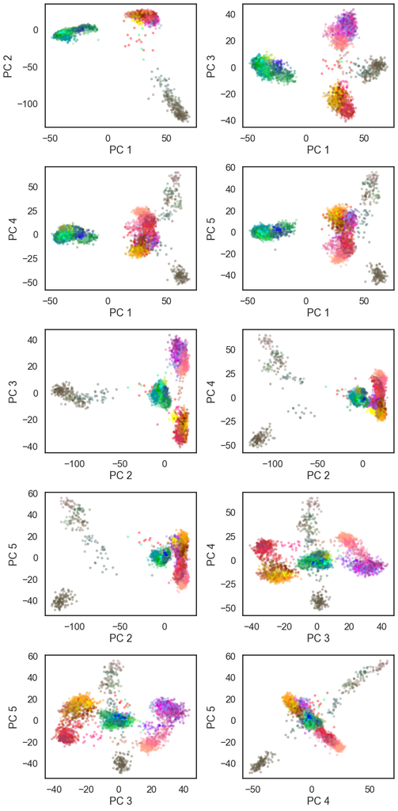

```python
color_per_datapoint = tasic_1k['clusterColors'][tasic_1k['clusters']]
plot_PCs(tasic_1k['PCA_75'],color_per_datapoint)
```

We can infer the following from:

1. The PC2 vs. PC1 plot: Because PC1 explains the highest variance in the data and PC2 explains the second most variation, so mean differences among clusters along the PC1 axis are actually larger than similar distances along PC2 axis. If two clusters of cells are most different along the PC1 axis, for example excitatory neurons (greenish colors) and parvalbumin positive interneurons (reddish colors), then such differences are likely to have occured due to the genes that have heavy influence on PC1 rather than on PC2. Similarly, non-neuron clusters (dark colors) are spaced the further from VIP positive interneurons (pinkish colors) along the PC2 axis rather than along the PC1 axis. So, in this case, the differences have occured due to the genes that affect most on PC2 rather than on PC1.
2. Other PCs vs PC1 plot: As PCs are ranked by how much they describe the data and PC1 reveals the most variation, so the variances/inter-cluster distances decrease along the axes for higher order PCs in comparison with the PC1 axes. Other interpretations are similar to those mentioned in point 1 above.
3. From all other plots: We see that as the order of principal components increases, their explained variances decrease and the cluster distances along the respective PC axes alse decrease. So the clusters along the $n+1$-th PC seem closer then the cluster along the $n$-th PC. Cluster distinction also diminishes as the order of PCs increases. This is evident from the fact that the five family of colors become less clustered and more spread out in the PC5 vs. PC4 plot in comparison to the PC2 vs. PC1 plot.

## Task 2: Comparison with PCA implemented by sklearn [5 pts]

We provide the results of the sklearn PCA to make sure you have the same PCA-transformed data as everyone else in the class in the remaining tasks and obtain some insights into numerical precision of the algorithms underlying PCA implementations.

```python
def PCA_sklearn(data):
    '''
    Function that performs PCA on the input data, using sklearn

    input: (cells,genes)-shaped array of log transformed cell counts
    output:
        fraction_variance_explained: (genes,)-shaped array with the fraction of variance explained by the individual PCs
        principal_components: (genes,genes)-shaped array containing the principal components as columns
    '''

    # INSERT YOUR CODE HERE
    pca = PCA(svd_solver='full') # initialize solver
    pca.fit_transform(data) # fit data
    principal_components = pca.components_.T # transpose as PCs are stored along rows and not along columns
    fraction_variance_explained = pca.explained_variance_ratio_ # explained variance ratio


    return fraction_variance_explained, principal_components
```

```python
#do sklearn-PCA on selected genes
var_expl_sklearn,PCs_sklearn = PCA_sklearn(tasic_1k['logCPM'])
#select components as before
_,PCs_sklearn75 = select_PCs(var_expl_sklearn,PCs_sklearn,0.75)
#get PC scores
PCA_75_sklearn = compute_PCA_scores(tasic_1k['logCPM'],PCs_sklearn75)
```

To see if your manual PCA yielded the same PC weights as the sklearn PCA, we can just take the two matrices of principle components and plot their entries against each other. (Note: This again assumes they are sorted by variance explained..)

Use the following plot to compare the results to your own implementation (here plotting the weights of the first 100 PCs against each other). What do you think where the noise comes from?

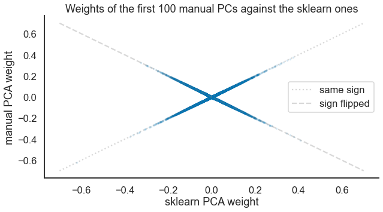

```python
n_evs_to_compare=100

plt.figure(figsize=(10,5))
plt.scatter(PCs_sklearn[:,:n_evs_to_compare].flatten(),PCs[:,:n_evs_to_compare].flatten(),s=5,alpha=0.1)
plt.plot([-.7,.7],[-.7,.7],':',c='tab:gray',label='same sign',alpha=0.3)
plt.plot([-.7,.7],[.7,-.7],'--',c='tab:gray',label='sign flipped',alpha=0.3)
plt.legend()
plt.xlabel('sklearn PCA weight')
plt.ylabel('manual PCA weight')
plt.title('Weights of the first %u manual PCs against the sklearn ones' % (n_evs_to_compare))

sns.despine()
```

```python
print('Variance explained by sklearn PC1 is: {}' .format(var_expl_sklearn[0]))
print('Variance explained by manual PC1 is: {}' .format(var_expl[0]))
```

```
Variance explained by sklearn PC1 is: 0.2309644459229929
Variance explained by manual PC1 is: 0.23096444592299215
```

Firstly, variances explained by PCs using both sklearn and manual implementation are almost same.

In both principal component analysis (PCA) and factor analysis (FA), we use the original variables, say $x_1,x_2,...,x_n$ to estimate several latent variables, say $z_1,z_2,...z_k$. These latent components are given by PCA or FA component scores. Each original variable is a linear combination of these components with some weights (or loadings in case of standardized scores). Flipping the sign of its scores also changes the signs of its loadings. This will have no influence on the interpretation, as PCA is just a linear combination of the scores with their loading. Also, changing the signs of the component(s), does not change the variance that is contained in the principal components. So, the interpretation stays exactly the same. This can be further explained as follows:

Suppose that we are doing the PCA regression of $y$ on component $1$ and the coefficient is positive. Then the larger the component $1$, the larger the y. Since the weight of the variable $1$ would also be positive, that shows that the larger the variable $1$, the larger the $y$.

Now, suppose in a second version the component has the sign changed, i.e. the larger the $y$, the smaller the component $1$. Meaning that the coefficient of $y$ over PC1 is now negative. But, so is the loading of the variable $1$. That means, the larger variable $1$, the smaller the component $1$, the larger $y$. Thus, the interpretation is the same.

It can be seen that the biplots get rotated by 180°. However, the relation between the weights/loadings and the data points remain exactly the same. Hence, the interpretation of the components is unchanged.

Additional reading about the sign of PCs: https://stats.stackexchange.com/questions/88880/does-the-sign-of-scores-or-of-loadings-in-pca-or-fa-have-a-meaning-may-i-revers

## Task 3: Nonlinear dimensionality reduction with t-SNE [5 pts]

In this task, you will use the nonlinear dimensionality reduction technique tSNE and look at visualizations of the data set. First, run the default t-SNE and store the result in a variable you keep, as you will use it for plotting in the next tasks as well. Plot the result of default t-SNE with the original cluster colors. For this and the following tasks, use the PCs explaining 75% of the variance you stored in `tasic_1k['PCA_75']` above.

```python
def plot_tsne(tsne_results, clusters=tasic_1k['clusters'], labels=['']):
    '''Plotting function for tsne results, creates one or multiple plots of tSNE-transformed data.
       If the clustering is the original one (default), original cluster colors will be used. Otherwise,
       colors will be a random permutation.

    input:
        tsne_results: (n,2)-shaped array containing tSNE-transformed data or list of such arrays
                      (output of the fit_transform function of sklearn tSNE)
        clusters: (n,)-shaped array containing cluster labels or list of such arrays
        labels: optional, list of titles for the subplots
    '''

    if type(tsne_results)==list: # make sure we can do both single and multiple plots and are flexible regarding input
        num_plots = len(tsne_results)
    else:
        num_plots = 1
        tsne_results = [tsne_results]
    if type(clusters)==list:
        num_clusters = len(clusters)
        num_plots = num_plots * num_clusters
        tsne_results = tsne_results * num_clusters
    else:
        clusters = [clusters]*num_plots

    if len(labels)==1:
        labels = labels*num_plots

    n_clusters = len(np.unique(clusters))      # ensure a long enough color list even if we plot more than
    n_colors = len(tasic_1k['clusterColors'])  # the original number of clusters
    if n_clusters > n_colors:
        n_extra_colors = n_clusters - n_colors
        colors = np.concatenate((tasic_1k['clusterColors'],tasic_1k['clusterColors'][:n_extra_colors]))
    else:
        colors = tasic_1k['clusterColors']

    fig, ax = plt.subplots(num_plots,1,figsize=(10,num_plots*10))
    if num_plots==1:
        if not np.all(tasic_1k['clusters']==clusters[0]):
            current_colors = np.random.permutation(colors)
        else:
            current_colors = colors
        ax.scatter(tsne_results[0][:,0], tsne_results[0][:,1], s=1, color=current_colors[clusters[0]])
        ax.set_title(labels[0])
        ax.set_xticks([])
        ax.set_yticks([])
        ax.set_axis_off()
    else:
        for i in range(num_plots):
            if not np.all(tasic_1k['clusters']==clusters[i]):
                current_colors = np.random.permutation(colors)
            else:
                current_colors = colors
            ax[i].scatter(tsne_results[i][:,0], tsne_results[i][:,1], s=1, color=current_colors[clusters[i]])
            ax[i].set_title(labels[i])
            ax[i].set_xticks([])
            ax[i].set_yticks([])
            ax[i].set_axis_off()
```

```python
original_clusters = tasic_1k['clusters']

# INSERT YOUR CODE HERE
tsne_results = TSNE().fit_transform(tasic_1k['PCA_75'])
```

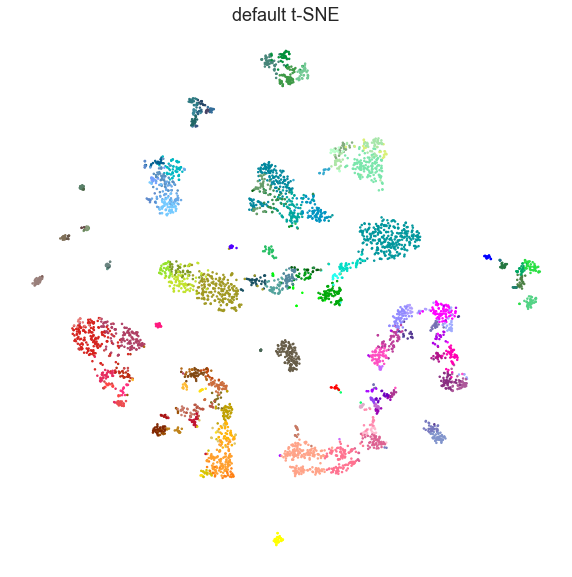

```python
plot_tsne(tsne_results,original_clusters,labels=['default t-SNE'])
```

t-SNE has one main parameter called perplexity, which trades of local and global structure. Its default value is 30. Run the tSNE with some other perplexity values (e.g. 5, 100), plot the results next to each other and explain what you observe. In particular, compare with the PCA plot above.

```python
# Try different perplexities

# INSERT YOUR CODE HERE
tsne_perplexity30 = TSNE(perplexity = 30).fit_transform(tasic_1k['PCA_75'])
tsne_perplexity5 = TSNE(perplexity = 5).fit_transform(tasic_1k['PCA_75'])
tsne_perplexity100 = TSNE(perplexity = 100).fit_transform(tasic_1k['PCA_75'])
tsne_perplexity = [tsne_perplexity30, tsne_perplexity5, tsne_perplexity100]
```

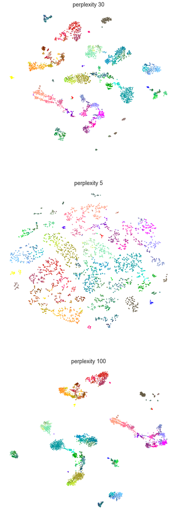

```python
# Plot results

plot_tsne(tsne_perplexity,original_clusters,labels=['perplexity 30', 'perplexity 5', 'perplexity 100'])
```

One of the features of t-SNE is a tuneable parameter, “perplexity,” which describes how to balance attention between local and global aspects of the data. The parameter is an estimate about the number of close neighbors each point has. So for small perplexity values, we see sparse clusters as in the case where $perplexity=5$. Whereas, many clusters are not distinctly separable for larger perplexity values such as, in the plot with $perplexity=100$. The default value for perplexity is $30$. On close observation of the plot of "default t-SNE" and "perplexity 30" it can be seen that same color coded clusters exist in the plots just at different positions.

More importantly, it is observed that t-SNE clusters are more refined in comparison to those seen in the PC-scores plots earlier. This indicates that the data requires a non-linear dimensionality reduction technique like that offered by t-SNE and that simple linear reduction as PCA does not suffice.

## Task 4: Cluster the data using k-Means [5 pts]

So far, we only visualized the data and plotted it with the original cluster labels. As a next step, we will implement k-Means as an example of a simple clustering algorithm and see how it performs on the dataset. Use the function KMeans provided by sklearn to perform K-Means with different numbers of clusters. Plot your results as cluster labels in the tSNE map and compare it to the original cluster labels. Describe your results.

```python
def run_KMeans(n_clusters):
    '''Function that performs K-means clustering for a given number of clusters
        input: number of clusters
        output: Cluster labels (K-means prediction)
    '''

    # INSERT YOUR CODE HERE
    n = n_clusters
    kmeans = KMeans(n_clusters = n, random_state=0).fit(tasic_1k['PCA_75'])
    kmeans_result = kmeans.labels_
    return kmeans_result
```

```python
# Run kmeans with different numbers of clusters (5, 10, 20, 50)

# INSERT YOUR CODE HERE
kmeans5 = run_KMeans(5)
kmeans10 = run_KMeans(10)
kmeans20 = run_KMeans(20)
kmeans50 = run_KMeans(50)
```

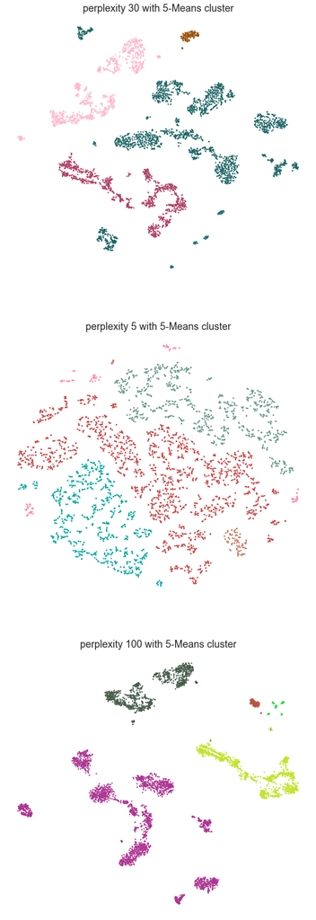

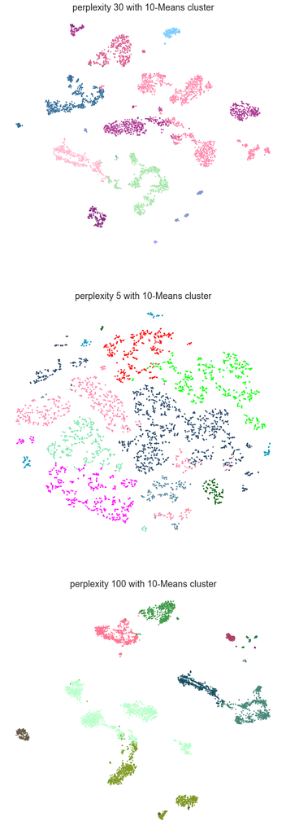

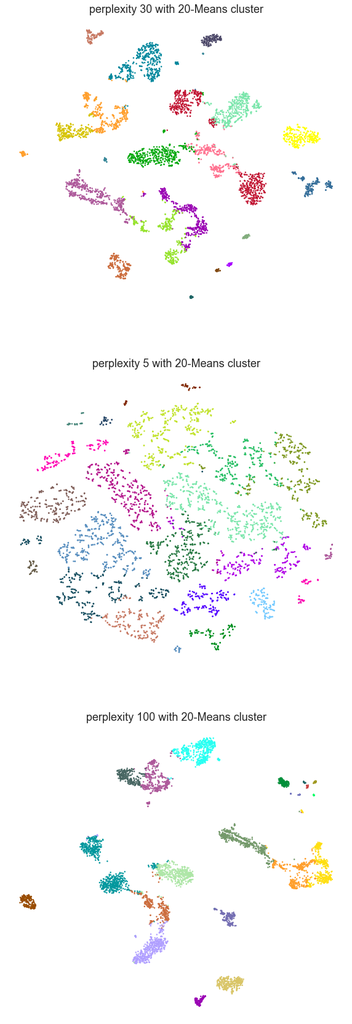

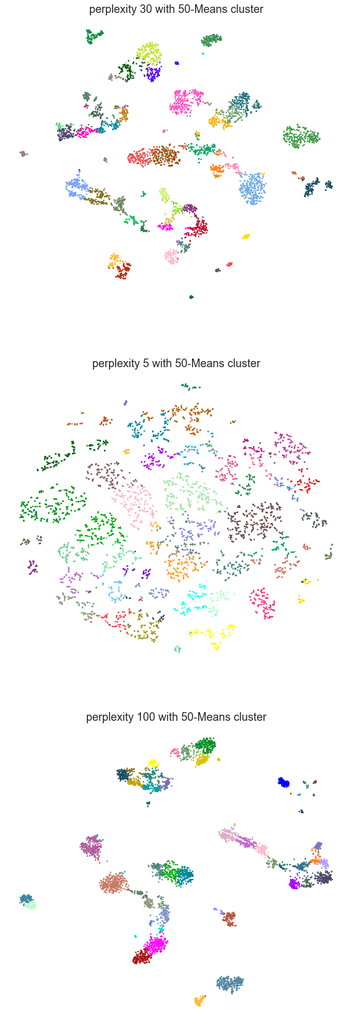

```python
# Plot results

# INSERT YOUR CODE HERE
plot_tsne(tsne_perplexity,kmeans5,labels=['perplexity 30 with 5-Means cluster', 'perplexity 5 with 5-Means cluster',
                                          'perplexity 100 with 5-Means cluster'])

plot_tsne(tsne_perplexity,kmeans10,labels=['perplexity 30 with 10-Means cluster', 'perplexity 5 with 10-Means cluster',
                                           'perplexity 100 with 10-Means cluster'])

plot_tsne(tsne_perplexity,kmeans20,labels=['perplexity 30 with 20-Means cluster', 'perplexity 5 with 20-Means cluster',
                                           'perplexity 100 with 20-Means cluster'])

plot_tsne(tsne_perplexity,kmeans50,labels=['perplexity 30 with 50-Means cluster', 'perplexity 5 with 50-Means cluster',
                                           'perplexity 100 with 50-Means cluster'])
```

Regardless of the perplexity value, it is evident that 5-Means and 10-Means cluster cannot adequately distinguish all the relevant clusters in the data. The same could be said about the 20-Means cluster looking a the repeated color clusters in different cluster locations. The 50-Means cluster, however, is able to sufficently distinguish the data into clusters with perplexity of $5$ being too sparse on one hand, while on the other cluster separation is somewhat indistinct with $perplexity=100$. So 50-Means cluster with perplexity $30$ seem to give a good overall cluster separation among the rest.

## Task 5: Clustering using Gaussian Mixture Models [20 points]

Finally, we will implement clustering with Gaussian Mixture models. To this end, we will first generate toy data to later verify the correct implementation of the algorithm and then implement the algorithm using EM and run it on the transcriptomics data set.

Sample 1000 data points from a two dimensional mixture of Gaussian model with three clusters and the following parameters:

$\mu_1 = \begin{bmatrix}0\\0\end{bmatrix}, \Sigma_1 = \begin{bmatrix}1 & 0\\0 & 1\end{bmatrix}, \pi_1=0.3$

$\mu_2 = \begin{bmatrix}5\\1\end{bmatrix}, \Sigma_2 = \begin{bmatrix}2 & 1\\1 & 2\end{bmatrix}, \pi_2=0.5$

$\mu_4 = \begin{bmatrix}0\\2\end{bmatrix}, \Sigma_3 = \begin{bmatrix}1 & -0.5\\-0.5 & 1\end{bmatrix}, \pi_3=0.2$

Plot the sampled data points and indicate in color the cluster each point came from. Plot the cluster means as well.

```python
import random
```

```python
def sampleData(N, means, covariances, priors):
    '''Generate N samples from a Mixture of Gaussian distribution.

    inputs:
        N           -- number of samples
        means       -- (n_cluster,n_dimensions)-shaped array of mean vectors
        covariances -- (n_dimensions,n_dimensions,n_cluster)-shaped array of covariance matrices
        prioirs     -- (n_cluster)-shaped arrays of priors / mixing coefficients
    outputs:
        data        -- (N,n_dimensions)-shaped array of simulated data
        cluster_ids -- (N,)-shaped array of integers that hold the cluster assignment for each data point

    '''

    # INSERT YOUR CODE HERE
    m = len(means)
    temp_data = [] # temporary data array
    temp_cluster_ids = [] # temporary cluster ID array

    random.seed(10)
    for i,mean in enumerate(means):
        # generate random data and set cluster IDs for each set of (mean, covariances) from multivariate normal distribution
        temp_data.append(np.random.multivariate_normal(mean, covariances[i], N))
        temp_cluster_ids.append([i]*N)

    # reshape to proper dimensions
    data = np.reshape(temp_data,(m*N,2))
    cluster_ids = np.reshape(temp_cluster_ids,(m*N))

    #shuffle the temporary data and cluster IDs and collect N many of those as sampled data
    indices = np.random.permutation(N*m)
    indices = indices[:N]
    data = data[indices]
    cluster_ids = cluster_ids[indices]

    return data,cluster_ids
```

```python
# Set up sampling

# INSERT YOUR CODE HERE
N = 1000
toy_means = [[0,0], [5,1], [0,2]]
toy_covs = [[[1,0],[0,1]], [[2,1],[1,2]], [[1,-0.5],[-0.5,1]]]
toy_priors = [0.3,0.5,0.2]
toy_data, toy_cluster_ids_true = sampleData(N, toy_means, toy_covs, toy_priors)
```

```python
def plot_clustering(data,cluster_ids,means,title):
    '''
    Plots the (2D) data as scatter plot, with different colors and an extra symbol for the mean per cluster.
    inputs:
        data        -- (N,n_dimensions)-shaped array of data
        cluster_ids -- (N,)-shaped array of integers that hold the cluster assignment for each data point
        means       -- (n_cluster,n_dimensions)-shaped array of mean vectors
        title       -- string that is added as title

    '''

    # INSERT YOUR CODE HERE
    n_clusters = len(np.unique(cluster_ids))   # number of unique clusters

    random.seed(10)
    number_of_colors = n_clusters # ensure a long enough color list
    colors = ["#"+''.join([random.choice('0123456789ABCDEF') for j in range(6)])
             for i in range(number_of_colors)]
    colors_per_datapoint = []

    for i in range(len(data)):
        colors_per_datapoint.append(colors[cluster_ids[i]])

    mean = np.reshape(means,np.shape(means))

    fig, ax = plt.subplots(1,1,figsize=(10,10))
    ax.scatter(data[:,0], data[:,1], s=3, color=colors_per_datapoint)
    ax.scatter(mean[:,0], mean[:,1], marker = r'$\circ$', s=500,alpha = 0.5, color=colors) # plot cluster means
    ax.set_title(title)
    ax.set_xticks([])
    ax.set_yticks([])
    ax.set_axis_off()
```

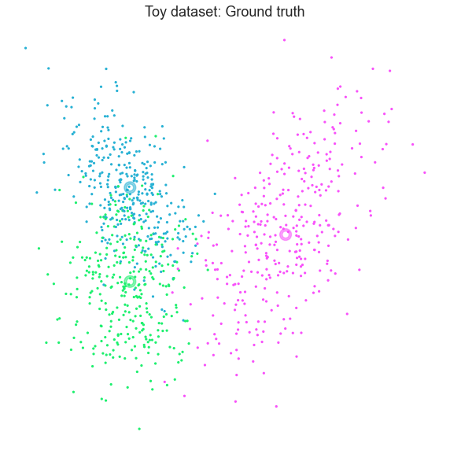

```python
plot_clustering(toy_data,toy_cluster_ids_true,toy_means,'Toy dataset: Ground truth')
```

Implement the EM algorithm to fit a Gaussian mixture model on the PCA-transformed data. Sort the data points by inferring their class labels from your mixture model (by using maximum a-posteriori classification). Fix the seed of the random number generator to ensure deterministic and reproducible behavior.

For this task, it is important to think about a good way to initialize the means, covariances and mixing coefficients. Also, during optimization, covariance matrices can become singular. To prevent this, you can add a small constant (like $10^{-6}$) to the diagonal.

```python
from scipy.stats import multivariate_normal
```

```python
def gmm(data,n_components,verbose=True,max_iter=1000):
    '''Function that fits a mixture of gaussians to data.

        inputs:
            data          -- (n_samples,n_features)-shaped array of data points
            n_components  -- int, number of clusters / mixture components
            verbose       -- bool, if True, print current likelihood after each EM iteration
            max_iter      -- maximum number of EM iterations

        outputs:
            cluster_ids -- (N,)-shaped array of integers that hold the cluster assignment for each data point
            means       -- (n_cluster,n_dimensions)-shaped array of fit mean vectors
            covs        -- (n_cluster,n_dimensions,n_dimensions)-shaped array of fit covariance matrices
            priors     -- (n_cluster)-shaped arrays of fit priors / mixing coefficients

        '''


    # INSERT YOUR CODE HERE



    ### INITIALIZATION ###
    n,m = data.shape
    k = n_components
    phi = np.full(shape=k, fill_value=1/k) # initialize priors as equal class probabilities
    weights = np.full( shape=data.shape, fill_value=1/k) # initialize equal weights

    # make temporary diagonal matrix to prevent singularity in covariance matrix
    temp = np.zeros((m, m), float)
    np.fill_diagonal(temp, 0.00000001)

    random.seed(10)
    random_row = np.random.randint(low=0, high=n, size=k)

    # initialize mu with random points from data
    # This ensures mu comes from within some cluster in the data
    mu = [ data[row_index,:]*0.9 for row_index in random_row ]
    sigma = [ np.cov(data.T)+temp for _ in range(k) ] # initialize covariance as sample covariance with non-zero diagonal


    ### ALTERNATE BETWEEN E & M STEP ###
    ll_old = 0 # initialize old likelihood
    ll_new = 0 # initialize new likelihood

        ### E-STEP ###
    # E-Step: update weights and phi holding mu and sigma constant

    # define a function to be used locally to predict weights and likelihoods in the E -step
    def predict_prob(data):
        likelihood = np.zeros( (n, k) )
        for i in range(k):
            distribution = multivariate_normal(
                mean=mu[i],
                cov=sigma[i])
            likelihood[:,i] = distribution.pdf(data)

        numerator = likelihood * phi # conditional probability*prior
        denominator = numerator.sum(axis=1)[:, np.newaxis]
        weights = numerator / denominator # posterior
        return weights,likelihood

    for iterations in range(max_iter): # update weights and phi holding mu and sigma constant
        weights = predict_prob(data)[0]
        phi = weights.mean(axis=0)

        ### M-STEP ###
        # M-Step: update mu and sigma holding phi and weights constant
        for i in range(k):
            weight = weights[:, [i]]
            total_weight = weight.sum()
            mu[i] = (data * weight).sum(axis=0) / total_weight
            sigma[i] = np.cov(data.T,
                aweights=(weight/total_weight).flatten(),
                bias=True)+temp

        ll_new = np.sum(predict_prob(data)[1]) # new total likelihood value

        ### CHECK FOR CONVERGENCE ###
        # stop if L(t+1)<L(t)+epsilon for some small epsilon. Here epsilon = tolerance = 0.001
        if np.abs(ll_new - ll_old) < 0.0001:
            print('Convergence achieved with tolerance = 0.0001 after {} iterations.' .format(iterations))
            break # exit iterative loop
        ll_old = ll_new


    ### ASSIGN CLUSTER LABELS ###
    cluster_ids = []
    cluster_ids = np.argmax(weights, axis=1) # maximum a-posteriori classification

    cluster_ids = np.reshape(cluster_ids,n)
    means = mu
    covs = sigma
    priors = phi
    return (cluster_ids, means, covs, priors)
```

Test your implementation on the toy dataset specifying the correct number of clusters and make sure the code works correctly.

```python
toy_cluster_ids_fit,toy_means_fit, toy_covs_fit, toy_priors_fit = gmm(toy_data,3)
```

```
Convergence achieved with tolerance = 0.0001 after 401 iterations.
```

Plot the data points from the toy dataset and indicate in color the cluster each point was assigned to by your model. How does the assignment compare to ground truth? If you run the algorithm multiple times, you will notice that some solutions provide suboptimal clustering solutions - depending on your initialization strategy.

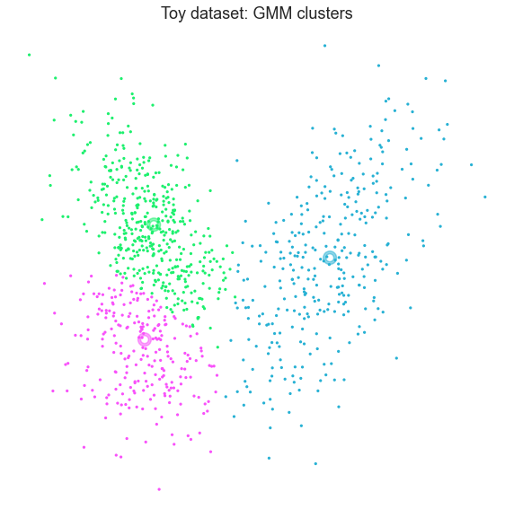

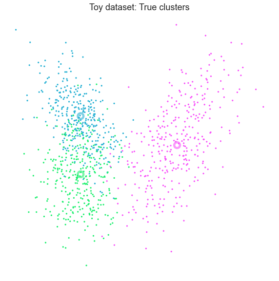

```python
plot_clustering(toy_data,toy_cluster_ids_fit,toy_means_fit,'Toy dataset: GMM clusters')
plot_clustering(toy_data,toy_cluster_ids_true,toy_means,'Toy dataset: True clusters')
```

It is seen that the GMM-algorithm classified the clusters almost similar to that of the original clusters (ignoring the difference in colors). It was also seen then when means were arbitrarily initialized, then the clustering was quite sporadic and sub-optimal. The GMM algorithm depends on how the means and covariances are initialized and the accuracy increases with better starting entries. So, it is important that at the least, the means come from the dataset and the covariance is the sample covariance.

Now apply your GMM implementation to the transcriptomics data using `n=50` clusters (as for the k-Means algorithm above). Compare the result to the result of the k-Means algorithm and the original clustering labels provided by the authors. What do you observe?

```python
GMM_cluster_ids_fit,GMM_means_fit, GMM_covs_fit, GMM_priors_fit = gmm(tsne_results,50)
```

```
Convergence achieved with tolerance = 0.0001 after 251 iterations.
```

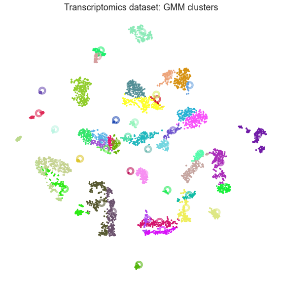

```python
plot_clustering(tsne_results,GMM_cluster_ids_fit,GMM_means_fit,'Transcriptomics dataset: GMM clusters')
```

Our GMM implementation to the transcriptomics data reveals some nice clusters. On close look it is seen that the clusters along with their means are quite distinctly separated and similar to the separation provided by the k-Means clustering with $k=50$ and default perplexity value.

```python
print('Original number of clusters is: {}' .format(len(np.unique(original_clusters))))
```

```
Original number of clusters is: 133
```

The authors originally provided $133$ clusters which conforms to the fact that $50$ clusters is not enough and that some cluster means overlap. Clusters in dark green, purple, yellow and a few others could be further separated into individual clusters.